# MNIST 실습

## CNN

- Step 1. MNIST 데이터셋 가져오기
- Step 2. Keras로 CNN 구성하기
- Step 3. Train 데이터로 학습하기
- Step 4. Test 데이터로 성능평가

MNIST 데이터셋은 얀 르쿤 교수님의 홈페이지에서 받을 수 있습니다.  
http://yann.lecun.com/exdb/mnist/

[figure not shown]

이 MNIST 데이터셋을 사용한 분류기(Classifier)들의 성능도 게시되어 있습니다.  
DNN으로는 `0.35`까지, CNN으로는 `0.23`까지 오류를 줄일 수 있었네요

[figure not shown]

MNIST 데이터셋은 총 6만 개의 학습(Train) 셋과 1만 개의 테스트(Test) 셋으로 구성되어 있습니다.

[figure not shown]

데이터셋의 내부에는 아래와 같은 포맷으로 작성되어 있습니다.

[figure not shown]

하지만 우리는 Keras의 데이터셋 함수를 이용해서 더 쉽게 이용해 보겠습니다! ^^

## 파이썬 라이브러리 불러오기

사용할 라이브러리들을 불러옵니다.

## 데이터셋 불러오기

Keras의 datasets를 이용해 MNIST 데이터셋을 불러오겠습니다.

```
X_train shape (60000, 28, 28)
y_train shape (60000,)
X_test shape (10000, 28, 28)
y_test shape (10000,)
```

불러온 데이터를 그림으로 한 번 그려보겠습니다.  
데이터가 많으니 무작위로 몇 개를 골라서 그려보겠습니다.  
셀을 다시 실행하면 또 다른 무작위 그림이 출력됩니다.

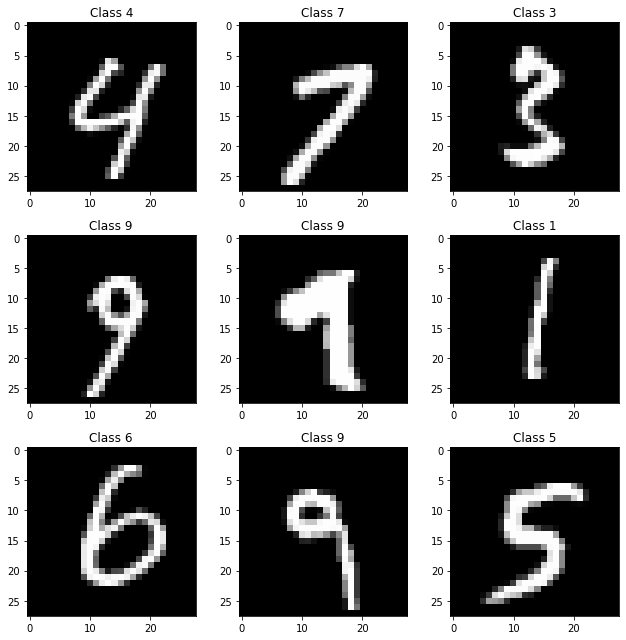

이미지 말고 배열로도 그려보겠습니다

```
0  0  0  0  0  0  0  0   0    0    0    0    0    0    0    0    0    0    0    0    0   0  0  0  0  0  0  0
0  0  0  0  0  0  0  0   0    0    0    0    0    0    0    0    0    0    0    0    0   0  0  0  0  0  0  0
0  0  0  0  0  0  0  0   0    0    0    0    0    0    0    0    0    0    0    0    0   0  0  0  0  0  0  0
0  0  0  0  0  0  0  0   0    0    0    0    0    0    0    0    0    0    0    0    0   0  0  0  0  0  0  0
0  0  0  0  0  0  0  0   0    0    0    0    0    0    0    0    0    0    0    0    0   0  0  0  0  0  0  0
0  0  0  0  0  0  0  0   0    0    0    0    0    0   36  146  254  255  251   95    6   0  0  0  0  0  0  0
0  0  0  0  0  0  0  0   0    0    0    0    3   97  234  254  254  232  254  254   35   0  0  0  0  0  0  0
0  0  0  0  0  0  0  0   0    0    0   89  140  254  254  174   67   33  200  254  190   0  0  0  0  0  0  0
0  0  0  0  0  0  0  0   0    0  108  253  254  235   51    1    0    0   12  254  253  56  0  0  0  0  0  0
0  0  0  0  0  0  0  0   0   12  216  254  244   55    0    0    0    0    6  213  254  57  0  0  0  0  0  0
0  0  0  0  0  0  0  0   0   25  254  254  132    0    0    0    0    0    0  168  254  57  0  0  0  0  0  0
0  0  0  0  0  0  0  0   0   45  254  243   34    0    0    0    0    0    0  168  254  57  0  0  0  0  0  0
0  0  0  0  0  0  0  0   0  128  254  157    0    0    0    0    0    0    0  168  254  57  0  0  0  0  0  0
0  0  0  0  0  0  0  0  19  228  254  105    0    0    0    0    0    0    7  228  254  57  0  0  0  0  0  0
0  0  0  0  0  0  0  0  58  254  254   87    0    0    0    0    0    0   10  254  246  47  0  0  0  0  0  0
0  0  0  0  0  0  0  0  58  254  254    9    0    0    0    0    0    0   10  254  210   0  0  0  0  0  0  0
0  0  0  0  0  0  0  0  58  254  254    9    0    0    0    0    0    0  105  254   91   0  0  0  0  0  0  0
0  0  0  0  0  0  0  0   5  219  254    9    0    0    0    0    0   24  230  254   24   0  0  0  0  0  0  0
0  0  0  0  0  0  0  0   0  216  254    9    0    0    0    0    0   84  254  251   23   0  0  0  0  0  0  0
0  0  0  0  0  0  0  0   0  216  254   36    0    0    0    0   22  208  251   94    0   0  0  0  0  0  0  0
0  0  0  0  0  0  0  0   0  129  254  120    0    0    0    3  140  254  229    0    0   0  0  0  0  0  0  0
0  0  0  0  0  0  0  0   0   83  254  222   17    0    0   91  254  236   53    0    0   0  0  0  0  0  0  0
0  0  0  0  0  0  0  0   0   18  235  254  134   21  119  237  254  124    0    0    0   0  0  0  0  0  0  0
0  0  0  0  0  0  0  0   0    0   53  249  254  234  252  254  172    3    0    0    0   0  0  0  0  0  0  0
0  0  0  0  0  0  0  0   0    0    0  116  237  254  254  133   20    0    0    0    0   0  0  0  0  0  0  0
0  0  0  0  0  0  0  0   0    0    0    0    0    0    0    0    0    0    0    0    0   0  0  0  0  0  0  0
0  0  0  0  0  0  0  0   0    0    0    0    0    0    0    0    0    0    0    0    0   0  0  0  0  0  0  0
0  0  0  0  0  0  0  0   0    0    0    0    0    0    0    0    0    0    0    0    0   0  0  0  0  0  0  0
==========
정답 : 0
```

각 픽셀은 8bit 정수이며, 0부터 255 사이의 값을 갖습니다.  
이미지에서 숫자 `0`은 검정, 숫자 `255`는 하양을 표현합니다.

이것을 싱글-채널 픽셀이라고 부르며, 단색(monochrome)이라고 합니다.

# 합성곱 (콘볼루션, Convolution)

CNN에서는 이미지의 특징들(곡률, 가장자리 등)을 신경망에 입력하고 신경망이 이미지 분류에 중요한 특징을 학습할 수 있도록 합니다.  
특징 입력을 위해서 합성곱(Convolution)을 사용할 겁니다.  
합성곱은 커널(kernel or filter)를 적용해서 특징맵(feature map)을 생성합니다.

[figure not shown]

위의 예에서 이미지는 5x5 행렬이고 여기에 합성곱을 할 커널은 3x3 행렬입니다.  
내적(dot product) 연산이 이미지와 커널 사이에서 발생하고 합성곱 된 특징맵이 만들어 집니다.  
CNN의 각 커널은 이미지의 다른 특성을 학습합니다.

커널은 사진 편집 소프트웨어에서 흐림(blur), 가장자리 감지(edge detection), 선명화(sharpening) 등을 적용하는 데 자주 사용됩니다.  
아래 표에서 필터의 값을 한 번 확인해 보세요.

https://en.wikipedia.org/wiki/Kernel_(image_processing)

[figure not shown]

여러 개의 커널(kernel or filter) 중 하나를 선택해서 직접 합성곱을 해보겠습니다.  
이미지는 숫자를 입력해서 하나 만들어 보죠!

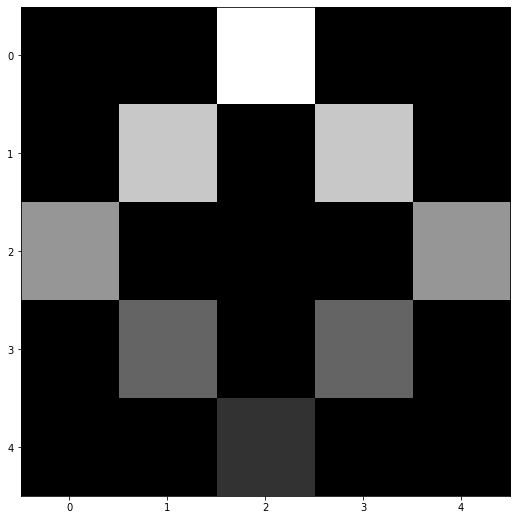

커널은 `Identity`를 사용해 볼께요.  
이 커널은 합성곱을 해도 이미지 그 자체가 그대로 나오는 항등 함수를 의미합니다

합성곱 연산은 옆으로 이동하면서 내려가면서 계산을 해야 하는데,  
직접 함수를 만들면 복잡하니 라이브러리 `scipy`의 신호 모듈에 들어 있는 `convolve2d` 함수를 쓰겠습니다.

```
[[200   0 200]
 [  0   0   0]
 [100   0 100]]
```

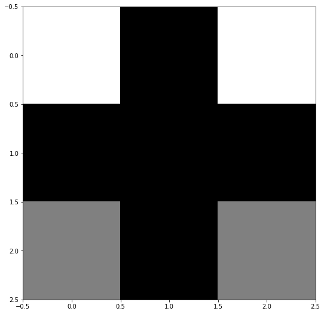

우리가 만들었던 이미지는 5x5 행렬이었는데,  
3x3 행렬 크기로 줄어들었습니다.

왜 그럴까요?

[figure not shown]

만약 이미지가 원래 크기를 유지하려 한다면, 패딩을 넣어주어야 합니다.  
패딩은 `numpy`의 `pad` 함수를 사용해서 해보겠습니다.

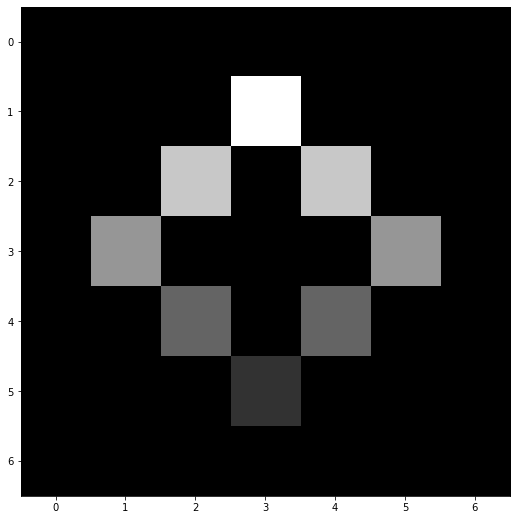

상하좌우로 1개의 빈칸이 늘어난 것을 볼 수 있습니다!  
이제 이 행렬에 합성곱을 해볼께요.

```
[[  0   0 255   0   0]
 [  0 200   0 200   0]
 [150   0   0   0 150]
 [  0 100   0 100   0]
 [  0   0  50   0   0]]
```

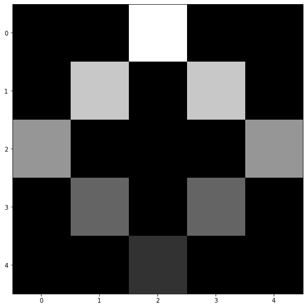

이미지 원래 크기 그 자체로 합성곱이 된 것을 확인할 수 있습니다!

이번에는 여러 커널(filter) 중 가장자리 감지를 사용해 보겠습니다.  
numpy `array`로 만들어 주세요.

```
[[-200 -455 1640 -455 -200]
 [-350 1195 -655 1195 -350]
 [ 900 -450 -600 -450  900]
 [-250  600 -250  600 -250]
 [-100 -150  200 -150 -100]]
```

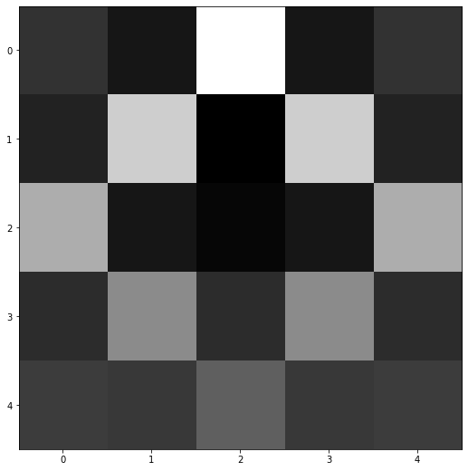

이미지 크기가 작다 보니 눈에 띄지 않는 것 같아요.  
실제 이미지를 한 번 불러오죠!

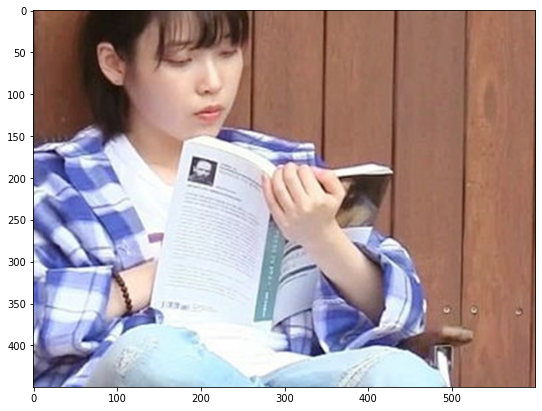

입력한 이미지는 4개의 차원을 가지고 있네요. 그건 Alpha 값이 더 들어 있어서 그렇습니다.  
3개의 RGB 색 행렬에 4번째 알파 채널이 추가되어 있습니다. 알파는 각 화소가 얼마나 투명한지를 나타내는 값이며, 이미지의 투명 채널을 PNG가 지원하기 때문에 추가되었습니다.

RGBA 색 공간 : https://ko.wikipedia.org/wiki/RGBA_%EC%83%89_%EA%B3%B5%EA%B0%84

```
(450, 600, 4)
```

각 색공간을 한 번 그려보겠습니다.

[figure not shown]

[figure not shown]

[figure not shown]

이 중에 R 공간에 대한 행렬만 가지고 합성곱을 해볼께요.

```
[[-1.92156851e-01 -3.52942050e-02  1.33333415e-01 ...  1.17647052e-02
   6.66666627e-02  8.23529363e-02]
 [-1.76470578e-01 -1.56863630e-02  1.21568710e-01 ...  1.96078420e-02
   5.88235259e-02  9.41176414e-02]
 [-1.64705873e-01 -8.94069672e-08  1.41176552e-01 ...  2.74509788e-02
   8.23529363e-02  7.05882311e-02]
 ...
 [ 3.92157435e-02  7.05882460e-02  8.62745047e-02 ...  1.96078420e-02
   5.49019575e-02 -3.92156839e-03]
 [-2.35293806e-02  5.88235259e-02  7.45097995e-02 ... -3.92156839e-03
   7.05882311e-02  6.27450943e-02]
 [ 3.13725621e-02  5.09803891e-02  7.84313679e-03 ... -1.17647052e-02
   7.05882311e-02  7.84313679e-02]]
```

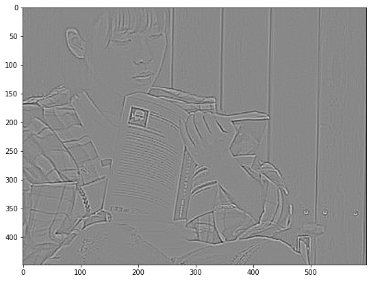

가장자리가 잘 추출되는 걸 볼 수 있습니다!

이번엔 다른 필터를 적용해 볼까요?  
**흐림**(blur)과 **선명화**(sharpen)을 해보겠습니다

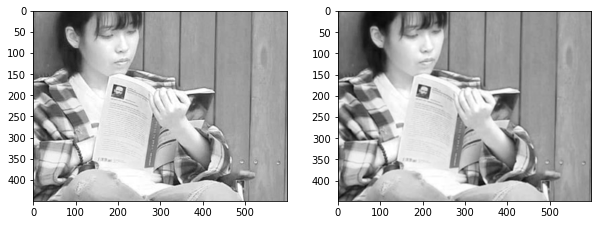

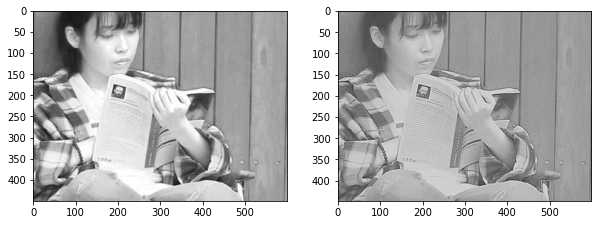

CNN에서 사용하는 커널은 위에서 사용한 커널들을 사용할 수도 있지만, 보통 최대 풀링(Max pooling)을 사용합니다.

**최대 풀링**은 가장 큰 값을 남기는 방식을 말합니다. 이는 작은 값 요소가 각 특징 맵에서 삭제되어 중요할 수 있는 부분만을 남기고 학습할 매개 변수 수를 줄이며 계산 비용(예 : 시스템 메모리)을 줄이는 효과가 있습니다.

- 앞으로 나아가는 매개 변수의 양을 줄여 계산 부하를 줄이기 위해서
- 값이 높은 픽셀이 가장 많이 활성화되어 잡아내기(capture) 위해서

[figure not shown]

컨볼루션의 컨볼루션을 취할 수도 있으며, Keras를 이용해 컨볼루션 층을 깊게 한 번 쌓아보도록 하죠!

[figure not shown]

## 깊은 CNN 만들기

```
X_train shape (60000, 28, 28)
y_train shape (60000,)
X_test shape (10000, 28, 28)
y_test shape (10000,)
학습 행렬 모양 : (60000, 28, 28, 1)
테스트 행렬 모양 (10000, 28, 28, 1)
```

Sequential()로 모델을 쌓아보겠습니다.

```
Model: "sequential"
_________________________________________________________________
Layer (type)                 Output Shape              Param #
=================================================================
conv2d (Conv2D)              (None, 26, 26, 32)        320
_________________________________________________________________
batch_normalization (BatchNo (None, 26, 26, 32)        128
_________________________________________________________________
activation (Activation)      (None, 26, 26, 32)        0
_________________________________________________________________
conv2d_1 (Conv2D)            (None, 24, 24, 32)        9248
_________________________________________________________________
batch_normalization_1 (Batch (None, 24, 24, 32)        128
_________________________________________________________________
activation_1 (Activation)    (None, 24, 24, 32)        0
_________________________________________________________________
max_pooling2d (MaxPooling2D) (None, 12, 12, 32)        0
_________________________________________________________________
conv2d_2 (Conv2D)            (None, 10, 10, 64)        18496
_________________________________________________________________
batch_normalization_2 (Batch (None, 10, 10, 64)        256
_________________________________________________________________
activation_2 (Activation)    (None, 10, 10, 64)        0
_________________________________________________________________
conv2d_3 (Conv2D)            (None, 8, 8, 64)          36928
_________________________________________________________________
batch_normalization_3 (Batch (None, 8, 8, 64)          256
_________________________________________________________________
activation_3 (Activation)    (None, 8, 8, 64)          0
_________________________________________________________________
max_pooling2d_1 (MaxPooling2 (None, 4, 4, 64)          0
_________________________________________________________________
flatten (Flatten)            (None, 1024)              0
_________________________________________________________________
dense (Dense)                (None, 512)               524800
_________________________________________________________________
batch_normalization_4 (Batch (None, 512)               2048
_________________________________________________________________
activation_4 (Activation)    (None, 512)               0
_________________________________________________________________
dropout (Dropout)            (None, 512)               0
_________________________________________________________________
dense_1 (Dense)              (None, 10)                5130
_________________________________________________________________
activation_5 (Activation)    (None, 10)                0
=================================================================
Total params: 597,738
Trainable params: 596,330
Non-trainable params: 1,408
_________________________________________________________________
```

하나의 테크닉으로 **데이터 증강(Data Augmentation)**을 수행하겠습니다.  
데이터 증강은 데이터를 무작위로 약간 변경하여 과적합(overfitting)을 방지합니다.  
Keras에는 자동 증강을 수행하는 훌륭한 내장(built-in) 기능이 있습니다.

만약 이미지의 양이 많다면, 제너레이터 형식으로 데이터를 입력시킬 수 있습니다.  
메모리에 모두 올려서 쓰는 것이 아니라 사용할 때 로드하여 사용하는 방식입니다. (이를 feeding 한다고 합니다)  
이 방법은 상당한 메모리 절약을 가져옵니다.

참고자료 : https://stanford.edu/~shervine/blog/keras-how-to-generate-data-on-the-fly

이 때 `steps_per_epoch`의 값은 샘플의 개수를 배치 사이즈로 나누어야 함을 잊지 마세요! $$\biggl\lfloor\frac{\#\textrm{ samples}}{\textrm{batch size}}\biggr\rfloor$$

```
Test score: 0.03446461632847786
Test accuracy: 0.9876000285148621
```

### 결과 살펴보기

- 정답인 경우

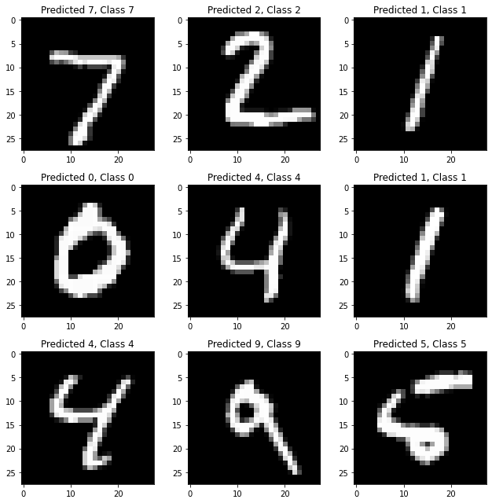

- 오답인 경우

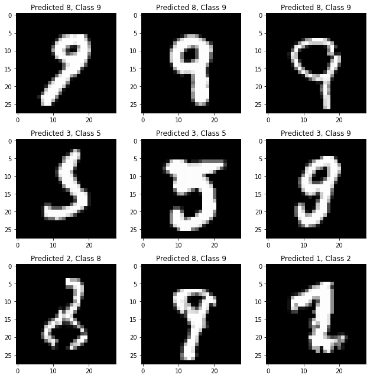

# 학습 시각화

딥러닝 모델은 Black Box 라고도 얘기하는데요, 잘 작동하는 모델이라도 왜 잘 작동하는지 그 내부를 사람이 이해하기 어렵기 때문입니다.

하지만 CNN은 할 수 있습니다! 시각적인 개념(이미지)을 학습한 것이기 때문에 그 내부도 시각화하기 매우 좋습니다.

## 중간층의 activation 시각화하기

중간층의 activation 시각화는 어떤 입력이 주어졌을 때 네트워크에 있는 여러 합성곱과 풀링 층이 출력하는 특성 맵을 그리는 것입니다.  
(layer의 출력이 활성화 함수의 출력이라서 **activation**이라고 부릅니다)

이 방법은 신경망에 의해 학습된 필터들이 **어떻게 입력을 분해하는지** 보여줍니다.

넓이, 높이, 깊이(채널) 3개의 차원에 대해 특성 맵을 시각화하는 것이 좋습니다.  
각 채널은 비교적 독립적인 특성을 인코딩하므로 특성 맵의 각 채널 내용을 독립적인 2D 이미지로 그리는 것이 괜찮은 방법입니다.

한 번 그려보겠습니다.

시각화를 하기 위해서 입력할 이미지 하나를 선택해 볼께요.

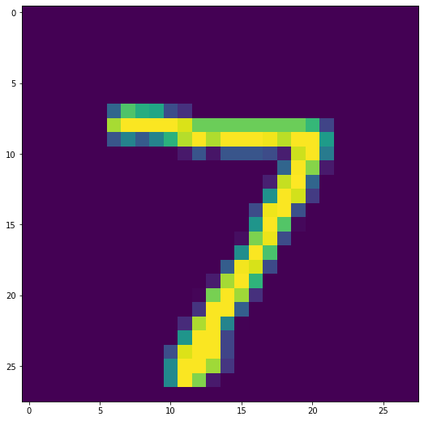

숫자 7을 가지고 한 번 해보겠습니다.  
모델에 사용하기 위해서 이미지를 4d tensor로 변경합니다.

우리 모델의 구조는 다음과 같았습니다.

```
Model: "sequential"
_________________________________________________________________
Layer (type)                 Output Shape              Param #
=================================================================
conv2d (Conv2D)              (None, 26, 26, 32)        320
_________________________________________________________________
batch_normalization (BatchNo (None, 26, 26, 32)        128
_________________________________________________________________
activation (Activation)      (None, 26, 26, 32)        0
_________________________________________________________________
conv2d_1 (Conv2D)            (None, 24, 24, 32)        9248
_________________________________________________________________
batch_normalization_1 (Batch (None, 24, 24, 32)        128
_________________________________________________________________
activation_1 (Activation)    (None, 24, 24, 32)        0
_________________________________________________________________
max_pooling2d (MaxPooling2D) (None, 12, 12, 32)        0
_________________________________________________________________
conv2d_2 (Conv2D)            (None, 10, 10, 64)        18496
_________________________________________________________________
batch_normalization_2 (Batch (None, 10, 10, 64)        256
_________________________________________________________________
activation_2 (Activation)    (None, 10, 10, 64)        0
_________________________________________________________________
conv2d_3 (Conv2D)            (None, 8, 8, 64)          36928
_________________________________________________________________
batch_normalization_3 (Batch (None, 8, 8, 64)          256
_________________________________________________________________
activation_3 (Activation)    (None, 8, 8, 64)          0
_________________________________________________________________
max_pooling2d_1 (MaxPooling2 (None, 4, 4, 64)          0
_________________________________________________________________
flatten (Flatten)            (None, 1024)              0
_________________________________________________________________
dense (Dense)                (None, 512)               524800
_________________________________________________________________
batch_normalization_4 (Batch (None, 512)               2048
_________________________________________________________________
activation_4 (Activation)    (None, 512)               0
_________________________________________________________________
dropout (Dropout)            (None, 512)               0
_________________________________________________________________
dense_1 (Dense)              (None, 10)                5130
_________________________________________________________________
activation_5 (Activation)    (None, 10)                0
=================================================================
Total params: 597,738
Trainable params: 596,330
Non-trainable params: 1,408
_________________________________________________________________
```

이 모델에서 첫 번째 레이어는 다음과 같이 선택할 수 있습니다.

```
<keras.layers.convolutional.Conv2D at 0x7f994feb95b0>
```

그리고 여러 개를 선택할 수도 있죠.

```
[<keras.layers.convolutional.Conv2D at 0x7f994feb95b0>,
 <keras.layers.normalization.BatchNormalization at 0x7f994feb9610>,
 <keras.layers.core.Activation at 0x7f996319dfa0>]
```

출력이 어떻게 생겼는지(dimension)는 `.output`을 통해 확인할 수 있습니다.

```
<KerasTensor: shape=(None, 26, 26, 32) dtype=float32 (created by layer 'conv2d')>
```

```
<KerasTensor: shape=(None, 26, 26, 32) dtype=float32 (created by layer 'activation')>
```

이 출력층만을 모델로 만들기 위해 모듈을 하나 import 합니다.  
모델 인스턴스를 만들 때는 두 개의 매개변수가 필요합니다. 입력텐서(inputs)와 출력텐서(outputs)입니다.

layer의 activation마다 하나씩 `14`개의 `numpy array`로 이루어진 리스트를 반환합니다.

```
14
```

첫 번째 conv layer의 activation 값을 한 번 그려보죠

```
(1, 26, 26, 32)
```

32개의 채널을 가진 26x26 크기의 특성 맵 입니다.

원본 모델의 첫 번째 layer activation 중에서 `5`번째 채널을 그려 보겠습니다.

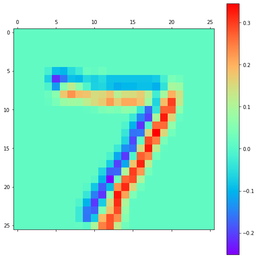

`5`번째 채널은 대각선 엣지를 감지하도록 인코딩된 것 같습니다.

`20`번째 채널을 볼까요?

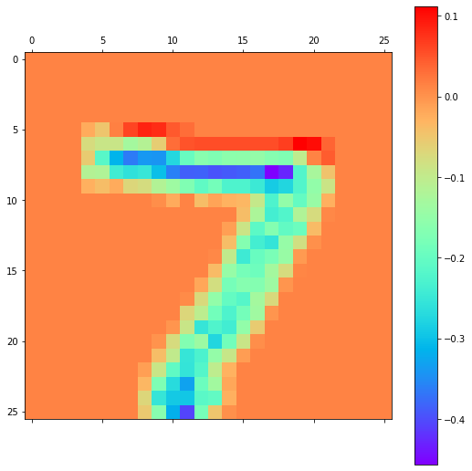

`20`번째 채널은 수평선 엣지를 감지하도록 인코딩된 것 같네요!

하나씩 살펴보면 귀찮으니 신경망의 모든 activation을 시각화해 보겠습니다.  
14개의 activation 맵에서 추출한 모든 채널을 그리기 위해 하나의 큰 이미지 텐서에 추출한 결과를 나란히 append 하겠습니다.

```
['conv2d',
 'batch_normalization',
 'activation',
 'conv2d_1',
 'batch_normalization_1',
 'activation_1',
 'max_pooling2d',
 'conv2d_2',
 'batch_normalization_2',
 'activation_2',
 'conv2d_3',
 'batch_normalization_3',
 'activation_3',
 'max_pooling2d_1']
```

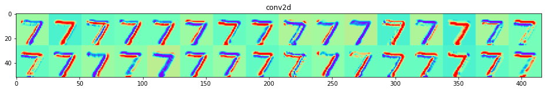

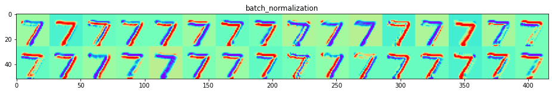

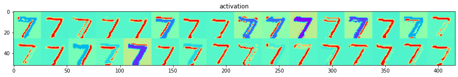

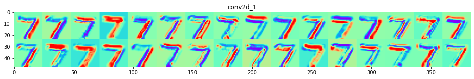

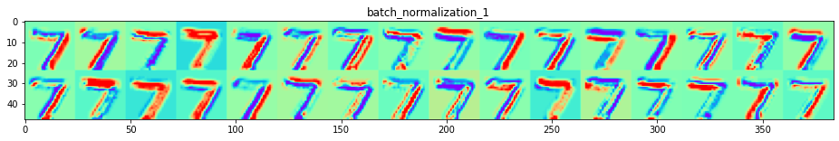

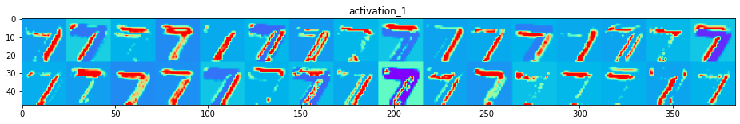

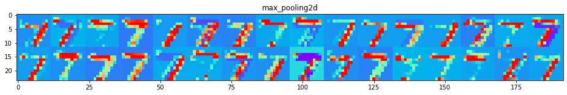

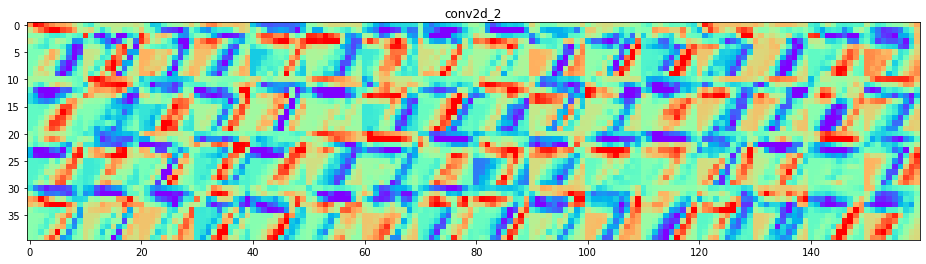

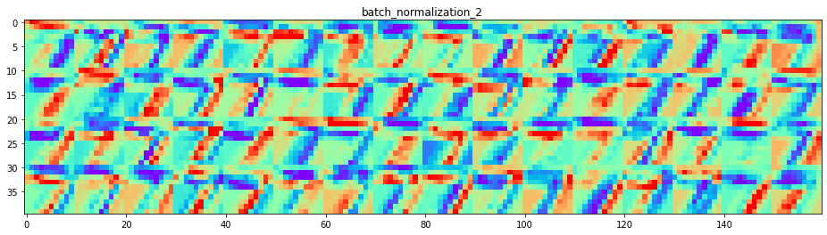

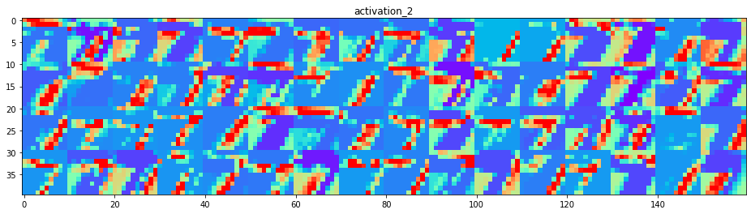

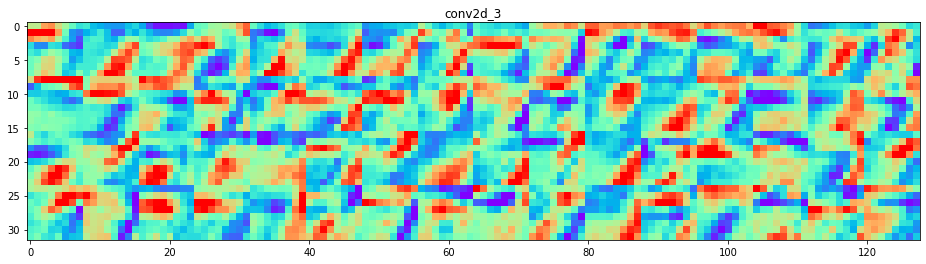

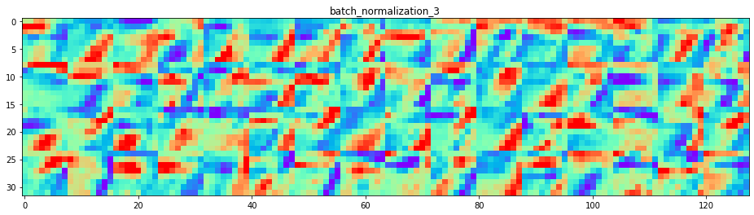

[2 more figures not shown]

이번엔 다른 숫자로 한 번 해볼까요?

# activation 시각화 도전!

각 시각화 층에서 주목되는 특징이 있지요?!  
이를 정리해 보면 다음과 같습니다.

- 첫 번째 layer는 여러 종류의 edge detector를 모아 놓은 것 같습니다.  
  이 단계의 activation에는 초기 사진에 있는 거의 모든 정보가 유지됩니다.
- 다음 layer로 갈수록 activation은 점점 더 추상적(abstract)으로 되고 시각적으로 이해하기 어려워집니다.  
  꺽인 부분, 둥근 부분 등 고수준(high-level) 개념을 인코딩하기 시작합니다.  
  상위 layer의 표현은 이미지의 시각적 콘텐츠에 대한 정보가 점점 줄어들고 타깃에 관한 정보가 점점 더 증가합니다.  
  깊은 신경망은 입력되는 원본 데이터에 대한 정보 정제 파이프라인처럼 작동합니다.  
  반복되는 변환을 통해 관계없는 정보를 걸러 내고 유용한 정보는 강조되면서 개선됩니다.

### 참고 자료

- https://github.com/wxs/keras-mnist-tutorial
- https://github.com/yashk2810/MNIST-Keras
- https://github.com/AviatorMoser/keras-mnist-tutorial
- http://ml-ko.kr/dl-with-python/5.4-visualizing-what-convnets-learn.html